# T1 - Positive Integer Collector

Create a program that collects positive integers from the user until user enters a negative integer. After this, the program should then display the collected integers along with their indices and ordinals. If no integers are entered, the program should gracefully handle the situation by displaying an appropriate message.

- **Input:** The program repeatedly prompt the user to enter positive integers. If the user enters a negative integer, the input process stops.
- **Validation:** Only positive integers should be collected. A negative integer stops the input collection.
- **Output:**
  - After input is stopped, the program will display the collected integers.
  - For each integer, show the following:
    - Index (starting from 0).
    - Ordinal (index + 1).
  - If there are no integers, inform the user that there are no integers to display.
- **Program Flow:**
  - The program starts with the message: “Program starting.”
  - Collect positive integers from the user.
  - Stop collecting on a negative number.
  - After stopping input, display the results.
  - The program ends with the message: “Program ending.”

Preferred datastructures:

- `list[int]`

**Example program runs:**

```
Program starting.
Collect positive integers.
Insert positive integer(negative stops): 5
Insert positive integer(negative stops): 10
Insert positive integer(negative stops): 15
Insert positive integer(negative stops): -1
Stopped collecting positive integers.
Displaying 3 integers:
- Index 0 => Ordinal 1 => Integer 5
- Index 1 => Ordinal 2 => Integer 10
- Index 2 => Ordinal 3 => Integer 15
Program ending.
```

```
Program starting.
Collect positive integers.
Insert positive integer(negative stops): 100
Insert positive integer(negative stops): 50
Insert positive integer(negative stops): 150
Insert positive integer(negative stops): -1
Stopped collecting positive integers.
Displaying 3 integers:
- Index 0 => Ordinal 1 => Integer 100
- Index 1 => Ordinal 2 => Integer 50
- Index 2 => Ordinal 3 => Integer 150
Program ending.
```

```
Program starting.
Collect positive integers.
Insert positive integer(negative stops): -1
Stopped collecting positive integers.
No integers to display.
Program ending.
```

```
Program starting.
Collect positive integers.
Insert positive integer(negative stops): 39
Insert positive integer(negative stops): 23
Insert positive integer(negative stops): 237
Insert positive integer(negative stops): 3
Insert positive integer(negative stops): 347
Insert positive integer(negative stops): 57
Insert positive integer(negative stops): 9
Insert positive integer(negative stops): 102
Insert positive integer(negative stops): 23
Insert positive integer(negative stops): 1000
Insert positive integer(negative stops): 37
Insert positive integer(negative stops): 19845
Insert positive integer(negative stops): 31
Insert positive integer(negative stops): 23
Insert positive integer(negative stops): 46
Insert positive integer(negative stops): 1490
Insert positive integer(negative stops): 38137
Insert positive integer(negative stops): 43535
Insert positive integer(negative stops): 2
Insert positive integer(negative stops): 114425
Insert positive integer(negative stops): 79
Insert positive integer(negative stops): 25
Insert positive integer(negative stops): 54258
Insert positive integer(negative stops): 2457
Insert positive integer(negative stops): 764
Insert positive integer(negative stops): -1
Stopped collecting positive integers.
Displaying 25 integers:
- Index 0 => Ordinal 1 => Integer 39
- Index 1 => Ordinal 2 => Integer 23
- Index 2 => Ordinal 3 => Integer 237
- Index 3 => Ordinal 4 => Integer 3
- Index 4 => Ordinal 5 => Integer 347
- Index 5 => Ordinal 6 => Integer 57
- Index 6 => Ordinal 7 => Integer 9
- Index 7 => Ordinal 8 => Integer 102
- Index 8 => Ordinal 9 => Integer 23
- Index 9 => Ordinal 10 => Integer 1000
- Index 10 => Ordinal 11 => Integer 37
- Index 11 => Ordinal 12 => Integer 19845
- Index 12 => Ordinal 13 => Integer 31
- Index 13 => Ordinal 14 => Integer 23
- Index 14 => Ordinal 15 => Integer 46
- Index 15 => Ordinal 16 => Integer 1490
- Index 16 => Ordinal 17 => Integer 38137
- Index 17 => Ordinal 18 => Integer 43535
- Index 18 => Ordinal 19 => Integer 2
- Index 19 => Ordinal 20 => Integer 114425
- Index 20 => Ordinal 21 => Integer 79
- Index 21 => Ordinal 22 => Integer 25
- Index 22 => Ordinal 23 => Integer 54258
- Index 23 => Ordinal 24 => Integer 2457
- Index 24 => Ordinal 25 => Integer 764
Program ending.
```

Example solution contains `36` lines of code.

# T2 - Analyse separated values

Create a Python program that processes a list of comma-separated integers entered by the user.

```
Insert comma separated integers: 2,2,1,3,12,8
```

The program will perform the following operations:

1. Parse the input, validate that all entries are valid integers.
2. If an invalid value is detected, output an error message indicating the invalid value, but still process the valid integers.
3. Calculate the sum of the valid integers and determine if the sum is even or odd.
4. Display the total count of valid integers, the sum of the integers, and whether the sum is even or odd.
5. If no valid integers are provided, display an appropriate message.

**Requirements:**

- **Input:**
  - The user inputs a comma-separated list of values.
  - The program parses these the entered values and checks if they are valid.
- **Output:**
  - If all values are valid, display the number of integers, their sum, and whether the sum is even or odd.
  - If invalid values have been entered, display an error message for the invalid value.
  - If no valid integers remain after parsing, inform the user that there are no values to analyze.

Preferred datastructures: `list[int]`

**Example program runs**

```
Program starting.
Insert comma separated integers: 2,2,1,3
There are 4 integers in the list.
Sum of the integers is 8 and it's even
Program ending.
```

```
Program starting.
Insert comma separated integers: 5,4,16,3,1
There are 5 integers in the list.
Sum of the integers is 29 and it's odd
Program ending.
```

```
Program starting.
Insert comma separated integers: 3,20,a,2
Invalid value 'a' detected.
There are 3 integers in the list.
Sum of the integers is 25 and it's odd
Program ending.
```

```
Program starting.
Insert comma separated integers: 39,23,237,3,347,57,9,102,23,1000,37,19845,31,23,46,1490,38137,43535,2,114425,79,25,54258,2457,764
There are 25 integers in the list.
Sum of the integers is 276994 and it's even
Program ending.
```

```
Program starting.
Insert comma separated integers: b
Invalid value 'b' detected.
No values to analyse.
Program ending.
```

Example solution contains `44` lines of code.

# T3 - Timestamp analysis

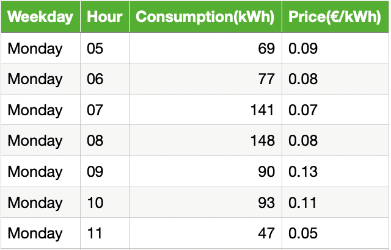

In this task, create a program that reads timestamps from a textfile. The file content is in “.csv” format and contains information related to electricity usage.

### Datasets

- A7_T3_D1.csv
- A7_T3_D2.csv
- A7_T3_D3.csv

**CSV format:**

- Has header row
- Columns
  - Weekday
  - Hour
  - Consumption(kWh)
  - Price(€/kWh)
- Separator `;`

Download the datasets to your computer and set up the following steps in your program:

1. Prompt user to insert the filename
2. Read the specified file
   1. Skip header row
   2. Read line and remove newline character
   3. If line is empty (contains only newline character), skip line
3. Analyse timestamps per weekday
   1. Count each row that starts with weekday (Row.startswith(…))
4. Display results

When analysing and creating results, the recommendation is to pass the data rows and the results list to the analyse function. This analyse function then reads the datarows, does the calculations and fills the results list when needed.

Displaying the results could be a function that simply iterates through the results and displays them. Below is a code example that can help structure the code for the task.

```python
WEEKDAYS = ("Monday", "Tuesday", "Wednesday", "Thursday", "Friday", "Saturnday", "Sunday",)

def readFile(PFilename: str, PRows: list[str]) -> None:
    print('Reading file "{}".'.format(PFilename))
    # 0. Clear PRows list just in case
    # 1. Open filehandle
    # 2. Read filehandle line-by-line
    # 2.1. Skip first line (header row)
    # 2.2. Check if line is empty '\n'
    # 2.3. Add non empty datarow without newline at the end.
    # 3. Close filehandle
    return None

def analyseTimestamps(PRows: list[str], PResults: list[str]) -> None:
    print("Analysing timestamps.")
    # Append results to the PResults list
    # Initialise helper list
    # WeekdayTimestampAmount: list[int] = [0, 0, 0, 0, 0, 0, 0]
    # Iterate rows with i
    #   Iterate WEEKDAYS with j
    #      Check if the row starts with the weekday name
    #          Count the day in proper place
    # Iterate WEEKDAYS with i and append the daily results
    # Clear the helper list
    return None

def displayResults(PResults: list[str]) -> None:
    print("Displaying results.")
    # Iterate results and print for the user
    return None

def main() -> None:
    # 1. Initialise
    # 1.1. Initialise rows list
    # 1.2. Initialise results list
    # 2. Operate
    # 2.1. Ask user to define filename
    # 2.2. Read file
    # 2.3. Analyse rows
    # 2.3. Display results
    # 3. Cleanup
    # 3.1. Clear lists
    return None

main()
```

Preferred datastructures:

- WEEKDAYS: `tuple[str]`
- Rows: `list[str]`
- Results: `list[str]`

You may run the program with single bash command:

```bash
echo -e "A7_T3_D1.csv\n" | python A7_T3.py
```

**Example program run:**

```
Program starting.
Insert filename: A7_T3_D1.csv
Reading file "A7_T3_D1.csv".
Analysing timestamps.
Displaying results.
### Timestamp analysis ###
 - Monday 24 stamps
 - Tuesday 24 stamps
 - Wednesday 0 stamps
 - Thursday 0 stamps
 - Friday 0 stamps
 - Saturnday 0 stamps
 - Sunday 0 stamps
### Timestamp analysis ###
Program ending.
```

```
Program starting.
Insert filename: A7_T3_D2.csv
Reading file "A7_T3_D2.csv".
Analysing timestamps.
Displaying results.
### Timestamp analysis ###
 - Monday 24 stamps
 - Tuesday 24 stamps
 - Wednesday 24 stamps
 - Thursday 24 stamps
 - Friday 24 stamps
 - Saturnday 24 stamps
 - Sunday 24 stamps
### Timestamp analysis ###
Program ending.
```

```
Program starting.
Insert filename: A7_T3_D3.csv
Reading file "A7_T3_D3.csv".
Analysing timestamps.
Displaying results.
### Timestamp analysis ###
 - Monday 23 stamps
 - Tuesday 24 stamps
 - Wednesday 22 stamps
 - Thursday 21 stamps
 - Friday 0 stamps
 - Saturnday 21 stamps
 - Sunday 19 stamps
### Timestamp analysis ###
Program ending.
```

Example solution contains `52` lines of code.

# T4 - Timestamp dataclass (TEST TASK)

Structure timestamp data in program.

This task is continuation to the A7_T3 task. You may start this task by copying the previous datasets. Rename datasets to match this task e.g., “A7_T3_D1.csv” => “A7_T4_D1.csv”.

The dataset had four different values separated by a semicolon `;`:

1. Weekday
2. Hour
3. Consumption(kWh)
4. Price(€/kWh)

The goal is to print each timestamp from a file and also calculate the total of consumption and price. Below is the output format for a single record.

```
Electiricity usages:
- Monday 12:00, price 0.20 €, consumption 15.00 kWh, total 3.00 €
- ...
```

To keep the code maintainable, define a named datastructure for the different values. Once defined, specify a way to read the timestamps into a list. This can be done by reading a file line by line, skipping empty lines, trimming line endings, and then splitting each line by the delimiter.

Code example of the operations:

```python
# Constants
DELIMITER = ";"
  # iterate over lines
    ...
    Row = Line.rstrip()               # Remove newline
    Columns = Row.split(DELIMITER)      # Splits the row into a list
    Timestamp = TIMESTAMP()           # Create object
    Timestamp.weekday = Columns[0]      # Collect the first column
    ...                               # Collect rest of the columns...
    Timestamp.price = float(Columns[3]) # Collect the fourth column and convert datatype
    Columns.clear()
```

Preferred datastructures:

- Timestamps: list[TIMESTAMP]

**Example program runs**

```
Program starting.
Insert filename: A7_T4_D1.csv
Reading file "A7_T4_D1.csv".
Electricity usage:
 - Monday 00:00, price 0.09, consumption 154.00 kWh, total 13.86 €
 - Monday 01:00, price 0.07, consumption 125.00 kWh, total 8.75 €
 - Monday 02:00, price 0.13, consumption 158.00 kWh, total 20.54 €
 - Monday 03:00, price 0.12, consumption 61.00 kWh, total 7.32 €
 - Monday 04:00, price 0.15, consumption 149.00 kWh, total 22.35 €
 - Monday 05:00, price 0.09, consumption 69.00 kWh, total 6.21 €
 - Monday 06:00, price 0.08, consumption 77.00 kWh, total 6.16 €
 - Monday 07:00, price 0.07, consumption 141.00 kWh, total 9.87 €
 - Monday 08:00, price 0.08, consumption 148.00 kWh, total 11.84 €
 - Monday 09:00, price 0.13, consumption 90.00 kWh, total 11.70 €
 - Monday 10:00, price 0.11, consumption 93.00 kWh, total 10.23 €
 - Monday 11:00, price 0.05, consumption 47.00 kWh, total 2.35 €
 - Monday 12:00, price 0.08, consumption 66.00 kWh, total 5.28 €
 - Monday 13:00, price 0.08, consumption 66.00 kWh, total 5.28 €
 - Monday 14:00, price 0.15, consumption 137.00 kWh, total 20.55 €
 - Monday 15:00, price 0.15, consumption 60.00 kWh, total 9.00 €
 - Monday 16:00, price 0.07, consumption 69.00 kWh, total 4.83 €
 - Monday 17:00, price 0.19, consumption 136.00 kWh, total 25.84 €
 - Monday 18:00, price 0.09, consumption 67.00 kWh, total 6.03 €
 - Monday 19:00, price 0.19, consumption 150.00 kWh, total 28.50 €
 - Monday 20:00, price 0.11, consumption 103.00 kWh, total 11.33 €
 - Monday 21:00, price 0.05, consumption 136.00 kWh, total 6.80 €
 - Monday 22:00, price 0.10, consumption 108.00 kWh, total 10.80 €
 - Monday 23:00, price 0.14, consumption 100.00 kWh, total 14.00 €
 - Tuesday 00:00, price 0.15, consumption 87.00 kWh, total 13.05 €
 - Tuesday 01:00, price 0.12, consumption 58.00 kWh, total 6.96 €
 - Tuesday 02:00, price 0.11, consumption 43.00 kWh, total 4.73 €
 - Tuesday 03:00, price 0.13, consumption 74.00 kWh, total 9.62 €
 - Tuesday 04:00, price 0.13, consumption 103.00 kWh, total 13.39 €
 - Tuesday 05:00, price 0.06, consumption 88.00 kWh, total 5.46 €
 - Tuesday 06:00, price 0.10, consumption 56.00 kWh, total 5.60 €
 - Tuesday 07:00, price 0.08, consumption 83.00 kWh, total 6.64 €
 - Tuesday 08:00, price 0.17, consumption 131.00 kWh, total 22.27 €
 - Tuesday 09:00, price 0.12, consumption 69.00 kWh, total 8.28 €
 - Tuesday 10:00, price 0.19, consumption 132.00 kWh, total 25.08 €
 - Tuesday 11:00, price 0.10, consumption 85.00 kWh, total 8.50 €
 - Tuesday 12:00, price 0.17, consumption 156.00 kWh, total 26.52 €
 - Tuesday 13:00, price 0.16, consumption 45.00 kWh, total 7.20 €
 - Tuesday 14:00, price 0.07, consumption 138.00 kWh, total 9.66 €
 - Tuesday 15:00, price 0.12, consumption 144.00 kWh, total 17.28 €
 - Tuesday 16:00, price 0.15, consumption 76.00 kWh, total 11.40 €
 - Tuesday 17:00, price 0.17, consumption 63.00 kWh, total 10.71 €
 - Tuesday 18:00, price 0.09, consumption 132.00 kWh, total 11.88 €
 - Tuesday 19:00, price 0.08, consumption 152.00 kWh, total 12.16 €
 - Tuesday 20:00, price 0.15, consumption 85.00 kWh, total 12.75 €
 - Tuesday 21:00, price 0.17, consumption 92.00 kWh, total 15.64 €
 - Tuesday 22:00, price 0.10, consumption 134.00 kWh, total 13.40 €
 - Tuesday 23:00, price 0.06, consumption 138.00 kWh, total 8.28 €
Program ending.
```

```
Program starting.
Insert filename: A7_T4_D2.csv
Reading file "A7_T4_D2.csv".
Electricity usage:
 - Monday 00:00, price 0.09, consumption 154.00 kWh, total 13.86 €
 - Monday 01:00, price 0.07, consumption 125.00 kWh, total 8.75 €
 - Monday 02:00, price 0.13, consumption 158.00 kWh, total 20.54 €
 - Monday 03:00, price 0.12, consumption 61.00 kWh, total 7.32 €
 - Monday 04:00, price 0.15, consumption 149.00 kWh, total 22.35 €
 - Monday 05:00, price 0.09, consumption 69.00 kWh, total 6.21 €
 - Monday 06:00, price 0.08, consumption 77.00 kWh, total 6.16 €
 - Monday 07:00, price 0.07, consumption 141.00 kWh, total 9.87 €
 - Monday 08:00, price 0.08, consumption 148.00 kWh, total 11.84 €
 - Monday 09:00, price 0.13, consumption 90.00 kWh, total 11.70 €
 - Monday 10:00, price 0.11, consumption 93.00 kWh, total 10.23 €
 - Monday 11:00, price 0.05, consumption 47.00 kWh, total 2.35 €
 - Monday 12:00, price 0.08, consumption 66.00 kWh, total 5.28 €
 - Monday 13:00, price 0.08, consumption 66.00 kWh, total 5.28 €
 - Monday 14:00, price 0.15, consumption 137.00 kWh, total 20.55 €
 - Monday 15:00, price 0.15, consumption 60.00 kWh, total 9.00 €
 - Monday 16:00, price 0.07, consumption 69.00 kWh, total 4.83 €
 - Monday 17:00, price 0.19, consumption 136.00 kWh, total 25.84 €
 - Monday 18:00, price 0.09, consumption 67.00 kWh, total 6.03 €
 - Monday 19:00, price 0.19, consumption 150.00 kWh, total 28.50 €
 - Monday 20:00, price 0.11, consumption 103.00 kWh, total 11.33 €
 - Monday 21:00, price 0.05, consumption 136.00 kWh, total 6.80 €
 - Monday 22:00, price 0.10, consumption 108.00 kWh, total 10.80 €
 - Monday 23:00, price 0.14, consumption 100.00 kWh, total 14.00 €
 - Tuesday 00:00, price 0.15, consumption 87.00 kWh, total 13.05 €
 - Tuesday 01:00, price 0.12, consumption 58.00 kWh, total 6.96 €
 - Tuesday 02:00, price 0.11, consumption 43.00 kWh, total 4.73 €
 - Tuesday 03:00, price 0.13, consumption 74.00 kWh, total 9.62 €
 - Tuesday 04:00, price 0.13, consumption 103.00 kWh, total 13.39 €
 - Tuesday 05:00, price 0.06, consumption 88.00 kWh, total 5.46 €
 - Tuesday 06:00, price 0.10, consumption 56.00 kWh, total 5.60 €
 - Tuesday 07:00, price 0.08, consumption 83.00 kWh, total 6.64 €
 - Tuesday 08:00, price 0.17, consumption 131.00 kWh, total 22.27 €
 - Tuesday 09:00, price 0.12, consumption 69.00 kWh, total 8.28 €
 - Tuesday 10:00, price 0.19, consumption 132.00 kWh, total 25.08 €
 - Tuesday 11:00, price 0.10, consumption 85.00 kWh, total 8.50 €
 - Tuesday 12:00, price 0.17, consumption 156.00 kWh, total 26.52 €
 - Tuesday 13:00, price 0.16, consumption 45.00 kWh, total 7.20 €
 - Tuesday 14:00, price 0.07, consumption 138.00 kWh, total 9.66 €
 - Tuesday 15:00, price 0.12, consumption 144.00 kWh, total 17.28 €
 - Tuesday 16:00, price 0.15, consumption 76.00 kWh, total 11.40 €
 - Tuesday 17:00, price 0.17, consumption 63.00 kWh, total 10.71 €
 - Tuesday 18:00, price 0.09, consumption 132.00 kWh, total 11.88 €
 - Tuesday 19:00, price 0.08, consumption 152.00 kWh, total 12.16 €
 - Tuesday 20:00, price 0.15, consumption 85.00 kWh, total 12.75 €
 - Tuesday 21:00, price 0.17, consumption 92.00 kWh, total 15.64 €
 - Tuesday 22:00, price 0.10, consumption 134.00 kWh, total 13.40 €
 - Tuesday 23:00, price 0.06, consumption 138.00 kWh, total 8.28 €
 - Wednesday 00:00, price 0.19, consumption 99.00 kWh, total 18.81 €
 - Wednesday 01:00, price 0.10, consumption 136.00 kWh, total 13.60 €
 - Wednesday 02:00, price 0.12, consumption 155.00 kWh, total 18.60 €
 - Wednesday 03:00, price 0.17, consumption 102.00 kWh, total 17.34 €
 - Wednesday 04:00, price 0.15, consumption 124.00 kWh, total 18.60 €
 - Wednesday 05:00, price 0.16, consumption 71.00 kWh, total 11.36 €
 - Wednesday 06:00, price 0.08, consumption 126.00 kWh, total 10.08 €
 - Wednesday 07:00, price 0.13, consumption 72.00 kWh, total 9.36 €
 - Wednesday 08:00, price 0.15, consumption 106.00 kWh, total 15.90 €
 - Wednesday 09:00, price 0.08, consumption 57.00 kWh, total 4.56 €
 - Wednesday 10:00, price 0.07, consumption 64.00 kWh, total 4.48 €
 - Wednesday 11:00, price 0.19, consumption 145.00 kWh, total 27.55 €
 - Wednesday 12:00, price 0.12, consumption 134.00 kWh, total 16.08 €
 - Wednesday 13:00, price 0.08, consumption 93.00 kWh, total 7.44 €
 - Wednesday 14:00, price 0.19, consumption 97.00 kWh, total 18.43 €
 - Wednesday 15:00, price 0.19, consumption 106.00 kWh, total 20.14 €
 - Wednesday 16:00, price 0.13, consumption 143.00 kWh, total 18.59 €
 - Wednesday 17:00, price 0.18, consumption 85.00 kWh, total 15.30 €
 - Wednesday 18:00, price 0.07, consumption 63.00 kWh, total 4.41 €
 - Wednesday 19:00, price 0.09, consumption 153.00 kWh, total 13.77 €
 - Wednesday 20:00, price 0.15, consumption 71.00 kWh, total 10.65 €
 - Wednesday 21:00, price 0.17, consumption 86.00 kWh, total 14.62 €
 - Wednesday 22:00, price 0.17, consumption 125.00 kWh, total 21.25 €
 - Wednesday 23:00, price 0.11, consumption 62.00 kWh, total 6.82 €
 - Thursday 00:00, price 0.10, consumption 80.00 kWh, total 8.00 €
 - Thursday 01:00, price 0.17, consumption 9.00 kWh, total 1.53 €
 - Thursday 02:00, price 0.19, consumption 26.00 kWh, total 4.94 €
 - Thursday 03:00, price 0.16, consumption 79.00 kWh, total 12.64 €
 - Thursday 04:00, price 0.15, consumption 36.00 kWh, total 5.40 €
 - Thursday 05:00, price 0.13, consumption 5.00 kWh, total 0.65 €
 - Thursday 06:00, price 0.10, consumption 37.00 kWh, total 3.70 €
 - Thursday 07:00, price 0.19, consumption 19.00 kWh, total 3.61 €
 - Thursday 08:00, price 0.19, consumption 58.00 kWh, total 11.02 €
 - Thursday 09:00, price 0.09, consumption 28.00 kWh, total 2.52 €
 - Thursday 10:00, price 0.09, consumption 47.00 kWh, total 4.23 €
 - Thursday 11:00, price 0.10, consumption 85.00 kWh, total 8.50 €
 - Thursday 12:00, price 0.11, consumption 99.00 kWh, total 10.89 €
 - Thursday 13:00, price 0.19, consumption 39.00 kWh, total 7.41 €
 - Thursday 14:00, price 0.07, consumption 11.00 kWh, total 0.77 €
 - Thursday 15:00, price 0.05, consumption 4.00 kWh, total 0.20 €
 - Thursday 16:00, price 0.12, consumption 64.00 kWh, total 7.68 €
 - Thursday 17:00, price 0.18, consumption 59.00 kWh, total 10.62 €
 - Thursday 18:00, price 0.07, consumption 29.00 kWh, total 2.03 €
 - Thursday 19:00, price 0.09, consumption 45.00 kWh, total 4.05 €
 - Thursday 20:00, price 0.15, consumption 15.00 kWh, total 2.25 €
 - Thursday 21:00, price 0.17, consumption 6.00 kWh, total 1.02 €
 - Thursday 22:00, price 0.17, consumption 71.00 kWh, total 12.07 €
 - Thursday 23:00, price 0.11, consumption 3.00 kWh, total 0.33 €
 - Friday 00:00, price 0.89, consumption 99.00 kWh, total 88.11 €
 - Friday 01:00, price 0.80, consumption 136.00 kWh, total 108.80 €
 - Friday 02:00, price 0.82, consumption 155.00 kWh, total 127.10 €
 - Friday 03:00, price 0.76, consumption 102.00 kWh, total 77.52 €
 - Friday 04:00, price 0.03, consumption 124.00 kWh, total 3.72 €
 - Friday 05:00, price 0.58, consumption 71.00 kWh, total 41.18 €
 - Friday 06:00, price 0.41, consumption 126.00 kWh, total 51.66 €
 - Friday 07:00, price 0.30, consumption 72.00 kWh, total 21.60 €
 - Friday 08:00, price 0.60, consumption 106.00 kWh, total 63.60 €
 - Friday 09:00, price 0.38, consumption 57.00 kWh, total 21.66 €
 - Friday 10:00, price 0.78, consumption 64.00 kWh, total 49.92 €
 - Friday 11:00, price 0.44, consumption 145.00 kWh, total 63.80 €
 - Friday 12:00, price 0.52, consumption 134.00 kWh, total 69.68 €
 - Friday 13:00, price 0.61, consumption 93.00 kWh, total 56.73 €
 - Friday 14:00, price 0.99, consumption 97.00 kWh, total 96.03 €
 - Friday 15:00, price 0.87, consumption 106.00 kWh, total 92.22 €
 - Friday 16:00, price 0.48, consumption 143.00 kWh, total 68.64 €
 - Friday 17:00, price 0.65, consumption 85.00 kWh, total 55.25 €
 - Friday 18:00, price 0.14, consumption 63.00 kWh, total 8.82 €
 - Friday 19:00, price 0.94, consumption 153.00 kWh, total 143.82 €
 - Friday 20:00, price 0.34, consumption 71.00 kWh, total 24.14 €
 - Friday 21:00, price 0.93, consumption 86.00 kWh, total 79.98 €
 - Friday 22:00, price 0.90, consumption 125.00 kWh, total 112.50 €
 - Friday 23:00, price 0.66, consumption 62.00 kWh, total 40.92 €
 - Saturnday 00:00, price 0.77, consumption 18.00 kWh, total 13.86 €
 - Saturnday 01:00, price 0.06, consumption 30.00 kWh, total 1.80 €
 - Saturnday 02:00, price 0.29, consumption 24.00 kWh, total 6.96 €
 - Saturnday 03:00, price 0.35, consumption 95.00 kWh, total 33.25 €
 - Saturnday 04:00, price 0.02, consumption 48.00 kWh, total 0.96 €
 - Saturnday 05:00, price 0.79, consumption 7.00 kWh, total 5.53 €
 - Saturnday 06:00, price 0.63, consumption 65.00 kWh, total 40.95 €
 - Saturnday 07:00, price 0.49, consumption 87.00 kWh, total 42.63 €
 - Saturnday 08:00, price 0.81, consumption 51.00 kWh, total 41.31 €
 - Saturnday 09:00, price 0.72, consumption 2.00 kWh, total 1.44 €
 - Saturnday 10:00, price 0.04, consumption 55.00 kWh, total 2.20 €
 - Saturnday 11:00, price 0.85, consumption 89.00 kWh, total 75.65 €
 - Saturnday 12:00, price 0.42, consumption 49.00 kWh, total 20.58 €
 - Saturnday 13:00, price 0.88, consumption 17.00 kWh, total 14.96 €
 - Saturnday 14:00, price 0.07, consumption 67.00 kWh, total 4.69 €
 - Saturnday 15:00, price 0.33, consumption 8.00 kWh, total 2.64 €
 - Saturnday 16:00, price 0.01, consumption 50.00 kWh, total 0.50 €
 - Saturnday 17:00, price 0.64, consumption 14.00 kWh, total 8.96 €
 - Saturnday 18:00, price 0.54, consumption 32.00 kWh, total 17.28 €
 - Saturnday 19:00, price 0.26, consumption 16.00 kWh, total 4.16 €
 - Saturnday 20:00, price 0.09, consumption 42.00 kWh, total 3.78 €
 - Saturnday 21:00, price 0.69, consumption 84.00 kWh, total 57.96 €
 - Saturnday 22:00, price 0.74, consumption 75.00 kWh, total 55.50 €
 - Saturnday 23:00, price 0.19, consumption 52.00 kWh, total 9.88 €
 - Sunday 00:00, price 0.39, consumption 67.00 kWh, total 26.13 €
 - Sunday 01:00, price 0.55, consumption 84.00 kWh, total 46.20 €
 - Sunday 02:00, price 0.08, consumption 27.00 kWh, total 2.16 €
 - Sunday 03:00, price 0.32, consumption 46.00 kWh, total 14.72 €
 - Sunday 04:00, price 0.20, consumption 16.00 kWh, total 3.20 €
 - Sunday 05:00, price 0.51, consumption 81.00 kWh, total 41.31 €
 - Sunday 06:00, price 0.92, consumption 93.00 kWh, total 85.56 €
 - Sunday 07:00, price 0.21, consumption 46.00 kWh, total 9.66 €
 - Sunday 08:00, price 0.98, consumption 91.00 kWh, total 89.18 €
 - Sunday 09:00, price 0.11, consumption 69.00 kWh, total 7.59 €
 - Sunday 10:00, price 0.10, consumption 57.00 kWh, total 5.70 €
 - Sunday 11:00, price 0.47, consumption 96.00 kWh, total 45.12 €
 - Sunday 12:00, price 0.25, consumption 62.00 kWh, total 15.50 €
 - Sunday 13:00, price 0.17, consumption 31.00 kWh, total 5.27 €
 - Sunday 14:00, price 0.95, consumption 72.00 kWh, total 68.40 €
 - Sunday 15:00, price 0.96, consumption 77.00 kWh, total 73.92 €
 - Sunday 16:00, price 0.12, consumption 94.00 kWh, total 11.28 €
 - Sunday 17:00, price 0.23, consumption 61.00 kWh, total 14.03 €
 - Sunday 18:00, price 0.15, consumption 13.00 kWh, total 1.95 €
 - Sunday 19:00, price 0.56, consumption 21.00 kWh, total 11.76 €
 - Sunday 20:00, price 0.37, consumption 54.00 kWh, total 19.98 €
 - Sunday 21:00, price 0.68, consumption 12.00 kWh, total 8.16 €
 - Sunday 22:00, price 0.70, consumption 10.00 kWh, total 7.00 €
 - Sunday 23:00, price 0.75, consumption 20.00 kWh, total 15.00 €
Program ending.
```

```
Program starting.
Insert filename: A7_T4_D3.csv
Reading file "A7_T4_D3.csv".
Electricity usage:
 - Monday 00:00, price 0.09, consumption 154.00 kWh, total 13.86 €
 - Monday 01:00, price 0.07, consumption 125.00 kWh, total 8.75 €
 - Monday 02:00, price 0.13, consumption 158.00 kWh, total 20.54 €
 - Monday 03:00, price 0.12, consumption 61.00 kWh, total 7.32 €
 - Monday 04:00, price 0.15, consumption 149.00 kWh, total 22.35 €
 - Monday 05:00, price 0.09, consumption 69.00 kWh, total 6.21 €
 - Monday 07:00, price 0.07, consumption 141.00 kWh, total 9.87 €
 - Monday 08:00, price 0.08, consumption 148.00 kWh, total 11.84 €
 - Monday 09:00, price 0.13, consumption 90.00 kWh, total 11.70 €
 - Monday 10:00, price 0.11, consumption 93.00 kWh, total 10.23 €
 - Monday 11:00, price 0.05, consumption 47.00 kWh, total 2.35 €
 - Monday 12:00, price 0.08, consumption 66.00 kWh, total 5.28 €
 - Monday 13:00, price 0.08, consumption 66.00 kWh, total 5.28 €
 - Monday 14:00, price 0.15, consumption 137.00 kWh, total 20.55 €
 - Monday 15:00, price 0.15, consumption 60.00 kWh, total 9.00 €
 - Monday 16:00, price 0.07, consumption 69.00 kWh, total 4.83 €
 - Monday 17:00, price 0.19, consumption 136.00 kWh, total 25.84 €
 - Monday 18:00, price 0.09, consumption 67.00 kWh, total 6.03 €
 - Monday 19:00, price 0.19, consumption 150.00 kWh, total 28.50 €
 - Monday 20:00, price 0.11, consumption 103.00 kWh, total 11.33 €
 - Monday 21:00, price 0.05, consumption 136.00 kWh, total 6.80 €
 - Monday 22:00, price 0.10, consumption 108.00 kWh, total 10.80 €
 - Monday 23:00, price 0.14, consumption 100.00 kWh, total 14.00 €
 - Tuesday 00:00, price 0.15, consumption 87.00 kWh, total 13.05 €
 - Tuesday 01:00, price 0.12, consumption 58.00 kWh, total 6.96 €
 - Tuesday 02:00, price 0.11, consumption 43.00 kWh, total 4.73 €
 - Tuesday 03:00, price 0.13, consumption 74.00 kWh, total 9.62 €
 - Tuesday 04:00, price 0.13, consumption 103.00 kWh, total 13.39 €
 - Tuesday 05:00, price 0.06, consumption 88.00 kWh, total 5.46 €
 - Tuesday 06:00, price 0.10, consumption 56.00 kWh, total 5.60 €
 - Tuesday 07:00, price 0.08, consumption 83.00 kWh, total 6.64 €
 - Tuesday 08:00, price 0.17, consumption 131.00 kWh, total 22.27 €
 - Tuesday 09:00, price 0.12, consumption 69.00 kWh, total 8.28 €
 - Tuesday 10:00, price 0.19, consumption 132.00 kWh, total 25.08 €
 - Tuesday 11:00, price 0.10, consumption 85.00 kWh, total 8.50 €
 - Tuesday 12:00, price 0.17, consumption 156.00 kWh, total 26.52 €
 - Tuesday 13:00, price 0.16, consumption 45.00 kWh, total 7.20 €
 - Tuesday 14:00, price 0.07, consumption 138.00 kWh, total 9.66 €
 - Tuesday 15:00, price 0.12, consumption 144.00 kWh, total 17.28 €
 - Tuesday 16:00, price 0.15, consumption 76.00 kWh, total 11.40 €
 - Tuesday 17:00, price 0.17, consumption 63.00 kWh, total 10.71 €
 - Tuesday 18:00, price 0.09, consumption 132.00 kWh, total 11.88 €
 - Tuesday 19:00, price 0.08, consumption 152.00 kWh, total 12.16 €
 - Tuesday 20:00, price 0.15, consumption 85.00 kWh, total 12.75 €
 - Tuesday 21:00, price 0.17, consumption 92.00 kWh, total 15.64 €
 - Tuesday 22:00, price 0.10, consumption 134.00 kWh, total 13.40 €
 - Tuesday 23:00, price 0.06, consumption 138.00 kWh, total 8.28 €
 - Wednesday 00:00, price 0.19, consumption 99.00 kWh, total 18.81 €
 - Wednesday 01:00, price 0.10, consumption 136.00 kWh, total 13.60 €
 - Wednesday 02:00, price 0.12, consumption 155.00 kWh, total 18.60 €
 - Wednesday 03:00, price 0.17, consumption 102.00 kWh, total 17.34 €
 - Wednesday 04:00, price 0.15, consumption 124.00 kWh, total 18.60 €
 - Wednesday 05:00, price 0.16, consumption 71.00 kWh, total 11.36 €
 - Wednesday 06:00, price 0.08, consumption 126.00 kWh, total 10.08 €
 - Wednesday 07:00, price 0.13, consumption 72.00 kWh, total 9.36 €
 - Wednesday 08:00, price 0.15, consumption 106.00 kWh, total 15.90 €
 - Wednesday 09:00, price 0.08, consumption 57.00 kWh, total 4.56 €
 - Wednesday 10:00, price 0.07, consumption 64.00 kWh, total 4.48 €
 - Wednesday 11:00, price 0.19, consumption 145.00 kWh, total 27.55 €
 - Wednesday 12:00, price 0.12, consumption 134.00 kWh, total 16.08 €
 - Wednesday 13:00, price 0.08, consumption 93.00 kWh, total 7.44 €
 - Wednesday 14:00, price 0.19, consumption 97.00 kWh, total 18.43 €
 - Wednesday 17:00, price 0.18, consumption 85.00 kWh, total 15.30 €
 - Wednesday 18:00, price 0.07, consumption 63.00 kWh, total 4.41 €
 - Wednesday 19:00, price 0.09, consumption 153.00 kWh, total 13.77 €
 - Wednesday 20:00, price 0.15, consumption 71.00 kWh, total 10.65 €
 - Wednesday 21:00, price 0.17, consumption 86.00 kWh, total 14.62 €
 - Wednesday 22:00, price 0.17, consumption 125.00 kWh, total 21.25 €
 - Wednesday 23:00, price 0.11, consumption 62.00 kWh, total 6.82 €
 - Thursday 00:00, price 0.10, consumption 80.00 kWh, total 8.00 €
 - Thursday 01:00, price 0.17, consumption 9.00 kWh, total 1.53 €
 - Thursday 02:00, price 0.19, consumption 26.00 kWh, total 4.94 €
 - Thursday 03:00, price 0.16, consumption 79.00 kWh, total 12.64 €
 - Thursday 04:00, price 0.15, consumption 36.00 kWh, total 5.40 €
 - Thursday 05:00, price 0.13, consumption 5.00 kWh, total 0.65 €
 - Thursday 06:00, price 0.10, consumption 37.00 kWh, total 3.70 €
 - Thursday 07:00, price 0.19, consumption 19.00 kWh, total 3.61 €
 - Thursday 08:00, price 0.19, consumption 58.00 kWh, total 11.02 €
 - Thursday 09:00, price 0.09, consumption 28.00 kWh, total 2.52 €
 - Thursday 10:00, price 0.09, consumption 47.00 kWh, total 4.23 €
 - Thursday 11:00, price 0.10, consumption 85.00 kWh, total 8.50 €
 - Thursday 12:00, price 0.11, consumption 99.00 kWh, total 10.89 €
 - Thursday 13:00, price 0.19, consumption 39.00 kWh, total 7.41 €
 - Thursday 14:00, price 0.07, consumption 11.00 kWh, total 0.77 €
 - Thursday 15:00, price 0.05, consumption 4.00 kWh, total 0.20 €
 - Thursday 19:00, price 0.09, consumption 45.00 kWh, total 4.05 €
 - Thursday 20:00, price 0.15, consumption 15.00 kWh, total 2.25 €
 - Thursday 21:00, price 0.17, consumption 6.00 kWh, total 1.02 €
 - Thursday 22:00, price 0.17, consumption 71.00 kWh, total 12.07 €
 - Thursday 23:00, price 0.11, consumption 3.00 kWh, total 0.33 €
 - Saturnday 00:00, price 0.77, consumption 18.00 kWh, total 13.86 €
 - Saturnday 01:00, price 0.06, consumption 30.00 kWh, total 1.80 €
 - Saturnday 02:00, price 0.29, consumption 24.00 kWh, total 6.96 €
 - Saturnday 03:00, price 0.35, consumption 95.00 kWh, total 33.25 €
 - Saturnday 04:00, price 0.02, consumption 48.00 kWh, total 0.96 €
 - Saturnday 05:00, price 0.79, consumption 7.00 kWh, total 5.53 €
 - Saturnday 06:00, price 0.63, consumption 65.00 kWh, total 40.95 €
 - Saturnday 07:00, price 0.49, consumption 87.00 kWh, total 42.63 €
 - Saturnday 08:00, price 0.81, consumption 51.00 kWh, total 41.31 €
 - Saturnday 09:00, price 0.72, consumption 2.00 kWh, total 1.44 €
 - Saturnday 10:00, price 0.04, consumption 55.00 kWh, total 2.20 €
 - Saturnday 11:00, price 0.85, consumption 89.00 kWh, total 75.65 €
 - Saturnday 12:00, price 0.42, consumption 49.00 kWh, total 20.58 €
 - Saturnday 13:00, price 0.88, consumption 17.00 kWh, total 14.96 €
 - Saturnday 14:00, price 0.07, consumption 67.00 kWh, total 4.69 €
 - Saturnday 15:00, price 0.33, consumption 8.00 kWh, total 2.64 €
 - Saturnday 16:00, price 0.01, consumption 50.00 kWh, total 0.50 €
 - Saturnday 17:00, price 0.64, consumption 14.00 kWh, total 8.96 €
 - Saturnday 18:00, price 0.54, consumption 32.00 kWh, total 17.28 €
 - Saturnday 19:00, price 0.26, consumption 16.00 kWh, total 4.16 €
 - Saturnday 23:00, price 0.19, consumption 52.00 kWh, total 9.88 €
 - Sunday 00:00, price 0.39, consumption 67.00 kWh, total 26.13 €
 - Sunday 01:00, price 0.55, consumption 84.00 kWh, total 46.20 €
 - Sunday 02:00, price 0.08, consumption 27.00 kWh, total 2.16 €
 - Sunday 03:00, price 0.32, consumption 46.00 kWh, total 14.72 €
 - Sunday 06:00, price 0.92, consumption 93.00 kWh, total 85.56 €
 - Sunday 07:00, price 0.21, consumption 46.00 kWh, total 9.66 €
 - Sunday 08:00, price 0.98, consumption 91.00 kWh, total 89.18 €
 - Sunday 09:00, price 0.11, consumption 69.00 kWh, total 7.59 €
 - Sunday 10:00, price 0.10, consumption 57.00 kWh, total 5.70 €
 - Sunday 11:00, price 0.47, consumption 96.00 kWh, total 45.12 €
 - Sunday 12:00, price 0.25, consumption 62.00 kWh, total 15.50 €
 - Sunday 13:00, price 0.17, consumption 31.00 kWh, total 5.27 €
 - Sunday 14:00, price 0.95, consumption 72.00 kWh, total 68.40 €
 - Sunday 15:00, price 0.96, consumption 77.00 kWh, total 73.92 €
 - Sunday 16:00, price 0.12, consumption 94.00 kWh, total 11.28 €
 - Sunday 17:00, price 0.23, consumption 61.00 kWh, total 14.03 €
 - Sunday 18:00, price 0.15, consumption 13.00 kWh, total 1.95 €
 - Sunday 22:00, price 0.70, consumption 10.00 kWh, total 7.00 €
 - Sunday 23:00, price 0.75, consumption 20.00 kWh, total 15.00 €
Program ending.
```

Example solution contains `55` lines of code.

# T5 - Electricity consumption (TEST TASK)

Analyse provided CSV data and create a summary of daily power usage and cost. Use the data from the A7_T3 task. Rename files accordingly e.g., “A7_T3_D1.csv” => “A7_T5_D1.csv”.

For the summary, calculate the daily power usage and the cost.

- **Daily usage:** Sum the consumption for each timestamp at the daily level. Use gatherer variable.
- **Daily cost:** Multiply the consumption by the daily timestamp’s corresponding price. Then sum the results into an gatherer-type variable.

Preferred datastructures:

- Timestamps: list[TIMESTAMP]
- Analysis helper: list[DAY_USAGE]
- Results: list[str]

**Example program runs**

```
Program starting.
Insert filename: A7_T5_D1.csv
Reading file "A7_T5_D1.csv".
Analysing timestamps.
Displaying results.
### Electricity consumption summary ###
 - Monday usage 2510.00 kWh, cost 279.42 €
 - Tuesday usage 2364.00 kWh, cost 286.46 €
 - Wednesday usage 0.00 kWh, cost 0.00 €
 - Thursday usage 0.00 kWh, cost 0.00 €
 - Friday usage 0.00 kWh, cost 0.00 €
 - Saturnday usage 0.00 kWh, cost 0.00 €
 - Sunday usage 0.00 kWh, cost 0.00 €
### Electricity consumption summary ###
Program ending.
```

```
Program starting.
Insert filename: A7_T5_D2.csv
Reading file "A7_T5_D2.csv".
Analysing timestamps.
Displaying results.
### Electricity consumption summary ###
 - Monday usage 2510.00 kWh, cost 279.42 €
 - Tuesday usage 2364.00 kWh, cost 286.46 €
 - Wednesday usage 2475.00 kWh, cost 337.74 €
 - Thursday usage 954.00 kWh, cost 126.06 €
 - Friday usage 2475.00 kWh, cost 1567.40 €
 - Saturnday usage 1077.00 kWh, cost 467.43 €
 - Sunday usage 1300.00 kWh, cost 628.78 €
### Electricity consumption summary ###
Program ending.
```

```
Program starting.
Insert filename: A7_T5_D3.csv
Reading file "A7_T5_D3.csv".
Analysing timestamps.
Displaying results.
### Electricity consumption summary ###
 - Monday usage 2433.00 kWh, cost 273.26 €
 - Tuesday usage 2364.00 kWh, cost 286.46 €
 - Wednesday usage 2226.00 kWh, cost 299.01 €
 - Thursday usage 802.00 kWh, cost 105.73 €
 - Friday usage 0.00 kWh, cost 0.00 €
 - Saturnday usage 876.00 kWh, cost 350.19 €
 - Sunday usage 1116.00 kWh, cost 544.37 €
### Electricity consumption summary ###
Program ending.
```

Example solution contains `84` lines of code.

# T6 - Rock Paper Scissors

[figure not shown]

Click to play in YouTube

Build “rock-paper-scissors” game in Python. In this game, there are two players, user and bot named “RPS-3PO”.

Rules for the RPS game:

1. Rock beats scissors
2. Paper beats rock
3. Scissors beat paper

ASCII Art below for the game.

```
    _______
---'   ____)
      (_____)
      (_____)
      (____)
---.__(___)
```

```
     _______
---'    ____)____
           ______)
          _______)
         _______)
---.__________)
```

```
    _______
---'   ____)____
          ______)
       __________)
      (____)
---.__(___)
```

In this exercise, place the following at the beginning of the code (right at the top). Setting the `seed` value means we are setting an initial state for the random number generator. After this, the generated numbers will follow exactly the same sequence. The random number will then depend on the number of calls to the random function.

```python
import random
random.seed(1234)
```

Randomize the bot’s choice in each game by calling the `random.randint(1, 3)` function with the given arguments. This function call returns a random integer between 1 and 3, inclusive. Implementing randomness in another way may lead to varying test results and is therefore not recommended.

The program start by asking for the player’s name. Then, greet the player and announce the opponent. After that, inform that the game is starting.

The menu contains 4 options, first three are game related options. If user chooses rock, paper or scissors from the menu, a round will be played.

Display text `"Rock! Paper! Scissors! Shoot!\n"`. Then, reveal the player’s choice first, followed by the bot’s choice. Show a decorative line of 25 hash (`#`) symbols between and around the choices to visually separate the player’s and the bot’s selections.

Then check the players’ choice according to the rules of the RPS game. If both players have chosen the same option, the result is a draw (`"Draw! Both players chose ____."`). Otherwise, declare the winner and the reason for the victory based on the condition.

**Example program runs**

```
Program starting.
Welcome to the rock-paper-scissors game!
Insert player name: John
Welcome John!
Your opponent is RPS-3PO.
Game starts...

Options:
1 - Rock
2 - Paper
3 - Scissors
0 - Quit game
Your choice: 1
Rock! Paper! Scissors! Shoot!

#########################
John chose rock.

    _______
---'   ____)
      (_____)
      (_____)
      (____)
---.__(___)

#########################
RPS-3PO chose paper.

     _______
---'    ____)____
           ______)
          _______)
         _______)
---.__________)

#########################

RPS-3PO paper beats John rock.

Options:
1 - Rock
2 - Paper
3 - Scissors
0 - Quit game
Your choice: 0

Results:
John - wins (0), losses (1), draws (0)
RPS-3PO - wins (1), losses (0), draws (0)

Program ending.
```

```
Program starting.
Welcome to the rock-paper-scissors game!
Insert player name: Jane
Welcome Jane!
Your opponent is RPS-3PO.
Game starts...

Options:
1 - Rock
2 - Paper
3 - Scissors
0 - Quit game
Your choice: 2
Rock! Paper! Scissors! Shoot!

#########################
Jane chose paper.

     _______
---'    ____)____
           ______)
          _______)
         _______)
---.__________)

#########################
RPS-3PO chose paper.

     _______
---'    ____)____
           ______)
          _______)
         _______)
---.__________)

#########################

Draw! Both players chose paper.

Options:
1 - Rock
2 - Paper
3 - Scissors
0 - Quit game
Your choice: 3
Rock! Paper! Scissors! Shoot!

#########################
Jane chose scissors.

    _______
---'   ____)____
          ______)
       __________)
      (____)
---.__(___)

#########################
RPS-3PO chose rock.

    _______
---'   ____)
      (_____)
      (_____)
      (____)
---.__(___)

#########################

RPS-3PO rock beats Jane scissors.

Options:
1 - Rock
2 - Paper
3 - Scissors
0 - Quit game
Your choice: 0

Results:
Jane - wins (0), losses (1), draws (1)
RPS-3PO - wins (1), losses (0), draws (1)

Program ending.
```

```
Program starting.
Welcome to the rock-paper-scissors game!
Insert player name: Bob
Welcome Bob!
Your opponent is RPS-3PO.
Game starts...

Options:
1 - Rock
2 - Paper
3 - Scissors
0 - Quit game
Your choice: 3
Rock! Paper! Scissors! Shoot!

#########################
Bob chose scissors.

    _______
---'   ____)____
          ______)
       __________)
      (____)
---.__(___)

#########################
RPS-3PO chose paper.

     _______
---'    ____)____
           ______)
          _______)
         _______)
---.__________)

#########################

Bob scissors beats RPS-3PO paper.

Options:
1 - Rock
2 - Paper
3 - Scissors
0 - Quit game
Your choice: 1
Rock! Paper! Scissors! Shoot!

#########################
Bob chose rock.

    _______
---'   ____)
      (_____)
      (_____)
      (____)
---.__(___)

#########################
RPS-3PO chose rock.

    _______
---'   ____)
      (_____)
      (_____)
      (____)
---.__(___)

#########################

Draw! Both players chose rock.

Options:
1 - Rock
2 - Paper
3 - Scissors
0 - Quit game
Your choice: 2
Rock! Paper! Scissors! Shoot!

#########################
Bob chose paper.

     _______
---'    ____)____
           ______)
          _______)
         _______)
---.__________)

#########################
RPS-3PO chose rock.

    _______
---'   ____)
      (_____)
      (_____)
      (____)
---.__(___)

#########################

Bob paper beats RPS-3PO rock.

Options:
1 - Rock
2 - Paper
3 - Scissors
0 - Quit game
Your choice: 0

Results:
Bob - wins (2), losses (0), draws (1)
RPS-3PO - wins (0), losses (2), draws (1)

Program ending.
```

Example solution contains `162` lines of code.

# T7 - Enigma machine

How did the Enigma Machine work?: https://youtu.be/ybkkiGtJmkM

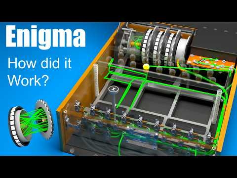

Click to play in YouTube

Implement Enigma machine in Python.

The program must handle:

- 3 x Rotors with 26 positions (A-Z)
- 1 x Reflector - Types A, B & C
- 0 x Plugboard. Prompt is required, but no need to implement.

The order of machine operations described:

1. User presses letter on the keyboard
   1. Keypress is passed via plugboard (skipped in this exercise)
   2. Rotate the wheels (positions)
   3. Scramble current letter using “Forward pass-through” process
      1. Iterate through rotors in order 1-3
         1. Create offset using current rotor position and the letter
         2. Use the offset to shift the given letter in alphabets
   4. Scramble current letter using using the reflector
   5. Scramble current letter using “Reverse pass-through” process
      1. Iterate through rotors in reverse order
      2. Change current letter based on each wheel position offset

In this program, user inserts row and the scrambling starts always from positions `[0, 0, 0]`. So enter press means that the program must reset the positions before scrambling the inserted text. The Enigma machine will shut down if the user enters an empty line.

Recommended datastructures:

- Rotors(characters): `list[str]`
- Positions(rotor positions): `list[int]`
- Reflector: `str`

### Enigma machine demo

Hover here to see the initial config “iconf1.txt” Rotor1:EKMFLGDQVZNTOWYHXUSPAIBRCJ  
Rotor2:AJDKSIRUXBLHWTMCQGZNPYFVOE  
Rotor3:BDFHJLCPRTXVZNYEIWGAKMUSQO  
Reflector:YRUHQSLDPXNGOKMIEBFZCWVJAT

Source code for this demo can be viewed using browser’s developer tools.

press `enter` to reset rotors to position 0 and rerun inserted text

**Initial configs**

- Tab 1: iconf1.txt
- Tab 2: iconf2.txt
- Tab 3: iconf3.txt

```
Rotor1:EKMFLGDQVZNTOWYHXUSPAIBRCJ
Rotor2:AJDKSIRUXBLHWTMCQGZNPYFVOE
Rotor3:BDFHJLCPRTXVZNYEIWGAKMUSQO
Reflector:YRUHQSLDPXNGOKMIEBFZCWVJAT
```

```
Rotor1:QAZWSXEDCRFVTGBYHNUJMIKOLP
Rotor2:PLMOKNIBJHVGYTFCXDRZESWAUQ
Rotor3:MNBVCXZLKJHGFDSAPOIUYTREWQ
Reflector:NOPQRSTUVWXYZABCDEFGHIJKLM
```

```
Rotor1:ZBFHUYXLTKOSQPAEGNIRMWJDVC
Rotor2:XNZJGBLHVUDFOQPTCIAMKSWYER
Rotor3:KPCYGRMSWLJOFTBUVNXQAIHZED
Reflector:FVPJIAOYEDRZXWGCTKUQSBNMHL
```

**Example program runs**

```
Insert config(filename): iconf1.txt
Insert plugs (y/n)?: n
No extra plugs inserted.
Enigma initialized.

Insert row (empty stops): HELLO
Character "H" illuminated as "E"
Character "E" illuminated as "C"
Character "L" illuminated as "M"
Character "L" illuminated as "A"
Character "O" illuminated as "M"
Converted row - "ECMAM".

Insert row (empty stops): ECMAM
Character "E" illuminated as "H"
Character "C" illuminated as "E"
Character "M" illuminated as "L"
Character "A" illuminated as "L"
Character "M" illuminated as "O"
Converted row - "HELLO".

Insert row (empty stops):

Enigma closing.
```

```
Insert config(filename): iconf2.txt
Insert plugs (y/n)?: n
No extra plugs inserted.
Enigma initialized.

Insert row (empty stops): HELLO
Character "H" illuminated as "C"
Character "E" illuminated as "L"
Character "L" illuminated as "O"
Character "L" illuminated as "S"
Character "O" illuminated as "X"
Converted row - "CLOSX".

Insert row (empty stops): CLOSX
Character "C" illuminated as "H"
Character "L" illuminated as "E"
Character "O" illuminated as "L"
Character "S" illuminated as "L"
Character "X" illuminated as "O"
Converted row - "HELLO".

Insert row (empty stops):

Enigma closing.
```

```
Insert config(filename): iconf3.txt
Insert plugs (y/n)?: n
No extra plugs inserted.
Enigma initialized.

Insert row (empty stops): HELLO
Character "H" illuminated as "E"
Character "E" illuminated as "C"
Character "L" illuminated as "B"
Character "L" illuminated as "N"
Character "O" illuminated as "K"
Converted row - "ECBNK".

Insert row (empty stops): ECBNK
Character "E" illuminated as "H"
Character "C" illuminated as "E"
Character "B" illuminated as "L"
Character "N" illuminated as "L"
Character "K" illuminated as "O"
Converted row - "HELLO".

Insert row (empty stops):

Enigma closing.
```

```
Insert config(filename): iconf1.txt
Insert plugs (y/n)?: n
No extra plugs inserted.
Enigma initialized.

Insert row (empty stops): ENIGMA MACHINE WORKING!
Character "E" illuminated as "H"
Character "N" illuminated as "X"
Character "I" illuminated as "B"
Character "G" illuminated as "C"
Character "M" illuminated as "O"
Character "A" illuminated as "J"
Character " " illuminated as " "
Character "M" illuminated as "B"
Character "A" illuminated as "I"
Character "C" illuminated as "D"
Character "H" illuminated as "P"
Character "I" illuminated as "G"
Character "N" illuminated as "K"
Character "E" illuminated as "F"
Character " " illuminated as " "
Character "W" illuminated as "I"
Character "O" illuminated as "M"
Character "R" illuminated as "P"
Character "K" illuminated as "T"
Character "I" illuminated as "W"
Character "N" illuminated as "W"
Character "G" illuminated as "J"
Character "!" illuminated as "!"
Converted row - "HXBCOJ BIDPGKF IMPTWWJ!".

Insert row (empty stops):

Enigma closing.
```

```
Insert config(filename): iconf1.txt
Insert plugs (y/n)?: n
No extra plugs inserted.
Enigma initialized.

Insert row (empty stops): THE QUICK BROWN FOX JUMPS OVER THE LAZY DOG
Character "T" illuminated as "M"
Character "H" illuminated as "D"
Character "E" illuminated as "C"
Character " " illuminated as " "
Character "Q" illuminated as "B"
Character "U" illuminated as "K"
Character "I" illuminated as "W"
Character "C" illuminated as "P"
Character "K" illuminated as "O"
Character " " illuminated as " "
Character "B" illuminated as "Y"
Character "R" illuminated as "D"
Character "O" illuminated as "N"
Character "W" illuminated as "A"
Character "N" illuminated as "Y"
Character " " illuminated as " "
Character "F" illuminated as "T"
Character "O" illuminated as "M"
Character "X" illuminated as "C"
Character " " illuminated as " "
Character "J" illuminated as "Q"
Character "U" illuminated as "Z"
Character "M" illuminated as "J"
Character "P" illuminated as "R"
Character "S" illuminated as "Z"
Character " " illuminated as " "
Character "O" illuminated as "H"
Character "V" illuminated as "A"
Character "E" illuminated as "P"
Character "R" illuminated as "O"
Character " " illuminated as " "
Character "T" illuminated as "W"
Character "H" illuminated as "R"
Character "E" illuminated as "I"
Character " " illuminated as " "
Character "L" illuminated as "N"
Character "A" illuminated as "L"
Character "Z" illuminated as "X"
Character "Y" illuminated as "L"
Character " " illuminated as " "
Character "D" illuminated as "V"
Character "O" illuminated as "F"
Character "G" illuminated as "Q"
Converted row - "MDC BKWPO YDNAY TMC QZJRZ HAPO WRI NLXL VFQ".

Insert row (empty stops):

Enigma closing.
```

Example solution contains ~`125` lines of code.